# ACTIVIDAD: COVID EN MÉXICO

Adylene Baylon

2024-02-05

## De epidemia a pandemia

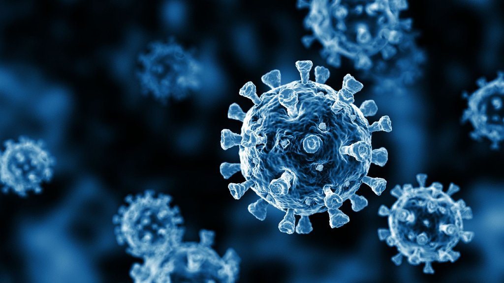

Imagen ilustrativa de coronavirus

## Antecedentes

- ¿Qué es el COVID19? Es un virus, causado por el SARS-CoV-2. Se transmite por vía aerea y causa diversos síntomas: tos, fiebre, dolor de cabeza, entre otros.
- ¿Cuál fue la situación en México entre 2020 y 2022? Cuándo se tuvieron los primeros contagios registrados en México, las autoridades correspondientes comenzarona a actuar para que no se propagara el virus, sin embargo, todo se salió de control, y no solo en el país, sino que en todo el mundo, así que de manera descontrolada hubo muertes de niños como adultos.
- ¿Cuál es el contexto de los datos que estamos usando? Se recomienda revisar el github del autor del paquete [https://github.com/RamiKrispin/coronavirus] para acceder a los detalles de los datos. También se puede probar con ??coronavirus en RStudio.

## Materiales y métodos

Citas:

- Se recomienda revisar el github del autor del paquete [https://github.com/RamiKrispin/coronavirus] para acceder a los detalles de los datos. También se puede probar con ??coronavirus en RStudio.

Para medir el impacto de una enfermedad:

- $TasaDeIncidencia = NuevosCasos / Población \times 100,000$
- $TasaDeMortalidad = Defunciones / Población \times 100,000$

## Resultados

- Nuevos casos confirmados en el tiempo (línea de tiempo sobre casos a nivel mundial).

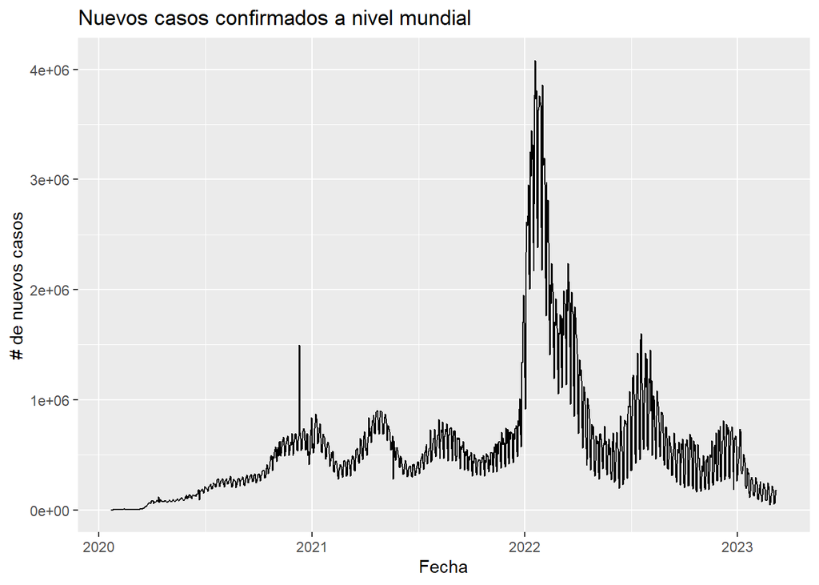

- Acumulativo de nuevos casos confirmados en el tiempo.

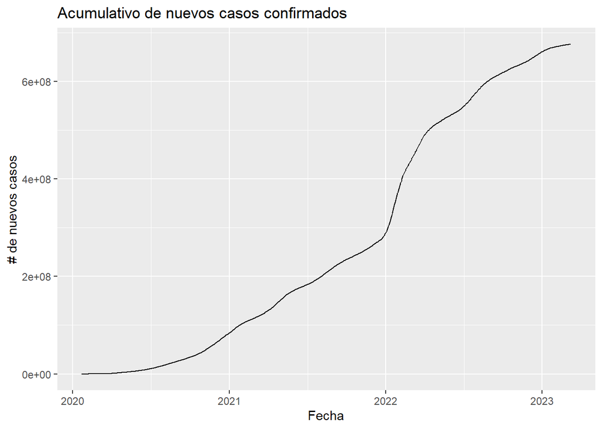

- Defunciones reportadas a nivel mundial.

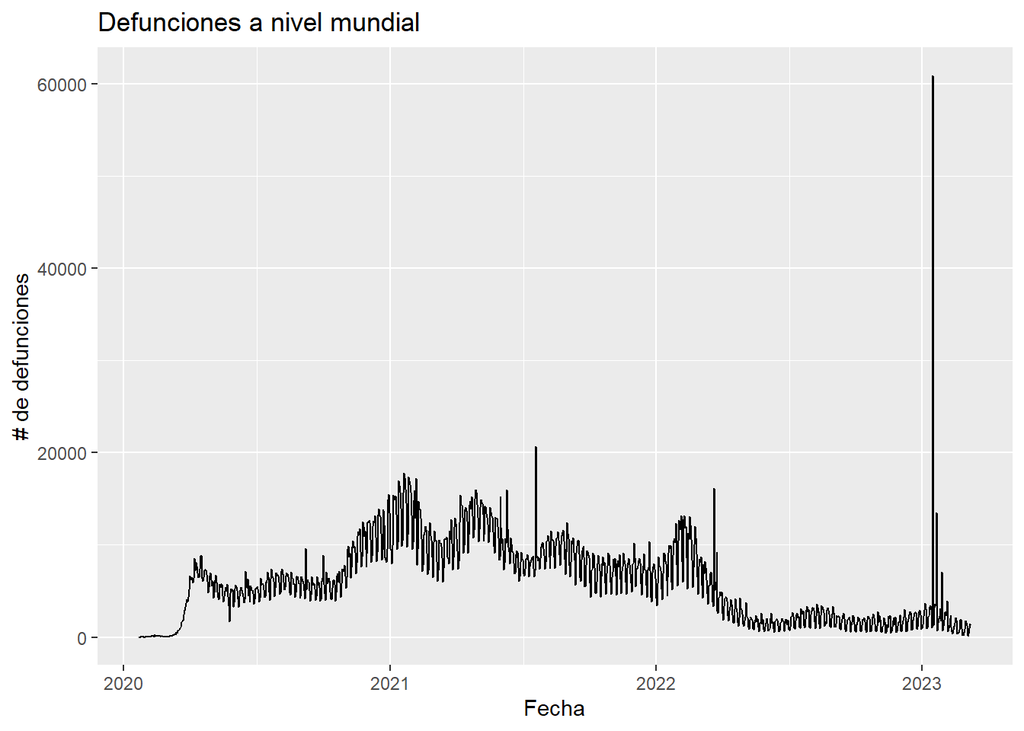

- Defunciones acumuladas a nivel mundial

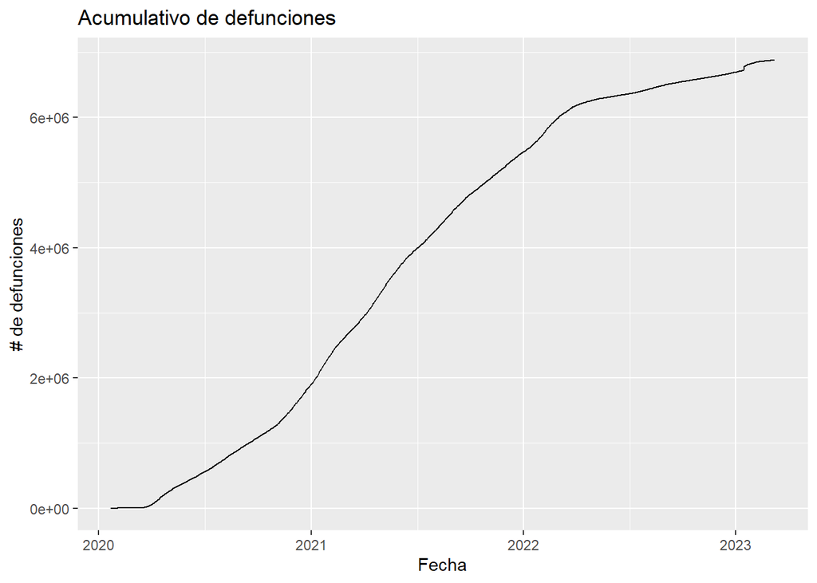

- Casos confirmados y defunciones en México (línea de tiempo sobre casos confirmados en México).

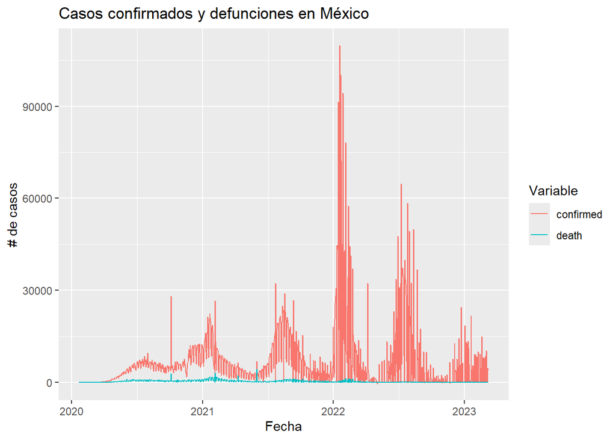

- Casos acumulados en México.

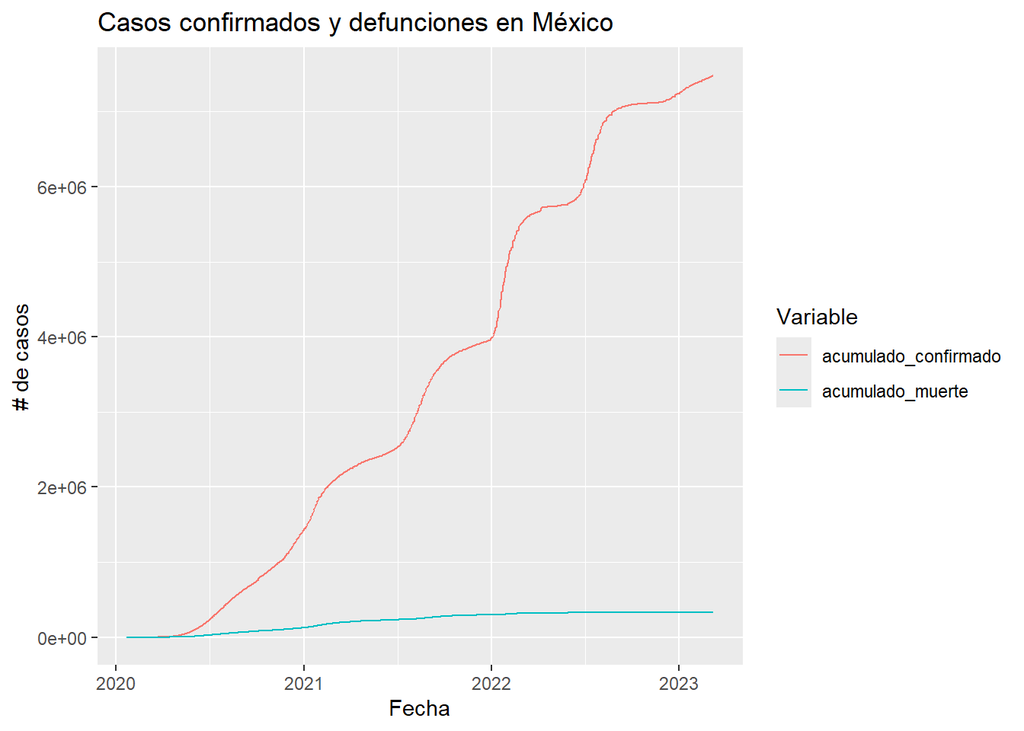

- Tasa de incidencia a nivel mundial por país, por año.
  - Presentar la información en un datatable, para facilitar el acceso a los datos.

|  | año | country | casos | poblacion | tasa_incidencia |
| --- | --- | --- | --- | --- | --- |
| 1 | 2020 | Afghanistan | 52330 | 38928341 | 134.4264837795168 |
| 2 | 2020 | Albania | 58316 | 2877800 | 2026.409062478282 |
| 3 | 2020 | Algeria | 99610 | 43851043 | 227.1553723362977 |
| 4 | 2020 | Andorra | 8049 | 77265 | 10417.39468064453 |
| 5 | 2020 | Angola | 17553 | 32866268 | 53.40734153327053 |
| 6 | 2020 | Antigua and Barbuda | 159 | 97928 | 162.3641859325218 |
| 7 | 2020 | Argentina | 1625514 | 45195777 | 3596.605939532802 |
| 8 | 2020 | Armenia | 159409 | 2963234 | 5379.561654597645 |
| 9 | 2020 | Australia | 28425 | 25459700 | 111.6470343326905 |
| 10 | 2020 | Austria | 356063 | 9006400 | 3953.444217445372 |

[output cut: 758 more lines]

- Tasa de mortalidad a nivel mundial por país
- Presentar la información en un datatable, para facilitar el acceso a los datos.

|  | año | country | casos | poblacion | tasa_mortalidad |
| --- | --- | --- | --- | --- | --- |
| 1 | 2020 | Afghanistan | 2189 | 38928341 | 5.623152550991064 |
| 2 | 2020 | Albania | 1181 | 2877800 | 41.03829314059351 |
| 3 | 2020 | Algeria | 2756 | 43851043 | 6.284913223158682 |
| 4 | 2020 | Andorra | 84 | 77265 | 108.716754028344 |
| 5 | 2020 | Angola | 405 | 32866268 | 1.23226646846548 |
| 6 | 2020 | Antigua and Barbuda | 5 | 97928 | 5.105792010456662 |
| 7 | 2020 | Argentina | 43245 | 45195777 | 95.68371841466517 |
| 8 | 2020 | Armenia | 2823 | 2963234 | 95.26753540219909 |
| 9 | 2020 | Australia | 909 | 25459700 | 3.570348433013743 |
| 10 | 2020 | Austria | 7486 | 9006400 | 83.11867116717 |

[output cut: 758 more lines]

- Indicar valores de tasa de incidencia y mortalidad para México

```
## # A tibble: 4 × 5
## # Groups:   año [4]
##   año   country   casos poblacion tasa_incidencia
##   <chr> <chr>     <dbl>     <dbl>           <dbl>
## 1 2020  Mexico  1426094 127792286           1116.
## 2 2021  Mexico  2553629 127792286           1998.
## 3 2022  Mexico  3254744 127792286           2547.
## 4 2023  Mexico   248977 127792286            195.
```

```
## # A tibble: 4 × 5
## # Groups:   año [4]
##   año   country  casos poblacion tasa_mortalidad
##   <chr> <chr>    <dbl>     <dbl>           <dbl>
## 1 2020  Mexico  125807 127792286           98.4
## 2 2021  Mexico  173621 127792286          136.
## 3 2022  Mexico   31671 127792286           24.8
## 4 2023  Mexico    2089 127792286            1.63
```

## Conclusiones

- Como hemos observado en los datos mostrados, las muertes en el comienzo de la pandemia fueron demasiado altos, sin embargo, al finalizar la pandemia, los casos de COVID fueron disminuyendo. *Asimismo, en la actualidad la situación está bajo control, y las autoridades correspondientes están presentes en cuanto a los casos que vayan surgiendo.

## Bibliografía

- Se agregan las referencias necesarias para citar los documentos y reportes utilizados.
- library(coronavirus)

# Pasos a seguir para subir el reporte a GitHub

1. Crear el repositorio en la web de GitHub. Se puede sugerir un nombre como “visualizacion_COVID19”.
2. Copiar la URL del repositorio remoto.
3. Pasar a la terminal en RStudio.
4. Verificar que el directorio de trabajo coincida con el directorio en donde está el reporte.
5. Inicializar el repositorio local `git init`
6. Añadir el archivo al área de preparación `git add Sesion2_Actividad.md`
7. Confirmar los cambios `git commit -m "Se carga archivo de reporte"`
8. Asignar un nombre de rama `git branch -M main`
9. Conectar los repositorios local y remoto `git remote add origin https://github.com/xxxUsrNmxxx/visualizacion_COVID19.git`
10. Llevar los cambios locales al repositorio remoto `git push -u origin main`

> [Nota]

> En caso de que RStudio no permita usar el nombre de usuario y contraseña para hacer la conexión remota se puede usar en vez de la contraseña un **Access token**.
> 1. En la página de GitHub hacer click en el ícono de perfil y luego en “Settings”.
> 2. En el menú del lado izquierdo, hacer click en la última opción “Developer settings”.
> 3. En el menú del lado izquierdo, hacer click en “Personal access tokens” y después en “Fine-grained tokens”.
> 4. Del lado derecho aparece el botón de “Generate new token”, hacer click ahí y confirmar con contraseña.
> 5. Se puede dar un nombre al token “Visualizacion COVID19”, cambiar el tiempo de expiración a 90 días y agregar alguna descripción. En la sección de “Repository access” seleccionar la tercera opción “Only select repositories” y escoger el repo adecuado.
> 6. Otorgar permisos adecuados. Para **Repository permissions** habilitar Actions, Administration, Commit statuses, Contents, Deployments, Environments, Metadata, Pages, Pull requests. Para **Account permissions** habilitar todo.
> 7. Copiar el token generado y usarlo como contraseña cuándo se hace el push.